# Estudios de Informática, Multimedia y Telecomunicaciones

# Mineria de dades: PRA1 - Selecció i preparació d’un joc de dades

Autor: Jordi Puig Ovejero

Abril 2020

Carrega de les llibreries que es necessiten

```r
library(ggpubr)
library(ggplot2)
library(arules)
library(dplyr)
library(factoextra)
library(FactoMineR)
```

# 1 Introducció

Aquesta pràctica cobreix de forma transversal l’assignatura.

Les Pràctiques 1 i 2 de l’assignatura es plantegen d’una forma conjunta de forma que la Pràctica 2 serà continuació de la 1.

Per aquesta primera pràctica el que farem és el següent:

1. Seleccionar un joc de dades i justificar la seva elecció. El joc de dades haurà de tenir capacitats perquè se li puguin aplicar algoritmes supervisats, algoritmes no supervisats i regles d’associació. Si el joc de dades no suporta els tres models, es poden triar diversos conjunts de dades, derivar dades noves o fusionar-los amb d’altres.
2. Realitzar una anàlisi exploratòria del joc de dades seleccionat.
3. Realitzar les tasques de neteja i condicionat necessàries per poder ser usat en processos de creació de models de mineria posteriors.
4. Realitzar mètodes de discretització
5. Aplicar un estudi PCA sobre el joc de dades. Tot i no estar explicat en el material didàctic, es valorarà si en lloc de PCA investigueu pel vostre compte i apliqueu SVD (Single Value Decomposition).

# 2 Elecció dels jocs de dades

Per a realitzar les dues pràctiques he pensat agafar dos jocs de dades. Em portarà una mica més de feina però ho he trobat adient. D’aquesta forma puc practicar amb diverses tipologies de datasets.

Nota: **Segurament a cada un dels jocs de dades apliqui més d’un tipus d’algoritme**.

# 3 Classificació

## 3.1 Joc de dades

Per a realitzar un estudi amb l’algoritme de classificació he agafat un dataset de [marqueting bancari](https://archive.ics.uci.edu/ml/datasets/Bank+Marketing).

Les dades estan relacionades amb campanyes de màrqueting directe d’una institució bancària portuguesa. Aquestes campanyes, basades en trucades de telèfon, buscaven clients que contractessin un dipòsit a termini. Sovint, es requeria més d’una trucada amb el mateix client per a concretar la transacció.

L’objectiu de la classificació és predir si el client subscriurà (“yes”/“no”) un dipòsit a termini (variable “y”) a partir d’una sèrie de dades del client (age, job, marital, education…). Si tenim una bona segmentació dels clients i fem una bona predicció el banc pot fer campanyes molt dirigides a obtenir resultats positius.

Durant l’exercici direm que un usuari ha convertit, és a dir, tenim una conversió, si y = ‘yes’. En cas contrari, direm que no ha convertit. El concepte **conversió** sortirà durant tot l’exercici.

Intentaré també en la pràctica 2 aplicar associació, buscant regles que ens donin com a resultat un target “yes”, “no”: (lhs => rhs, on rhs és “yes” or “no”). Clustering també podríem aplicar generant un model a partir de les dades dels client i trobant grups de clients.

**Hi ha quatre conjunts de dades:**

1. bank-adicional-full.csv amb tots els exemples (41188) i 20 atributs, ordenats per data (05/2008 - 11/2010)
2. bank-adicional.csv amb un 10% dels exemples (4119), seleccionats aleatòriament del 1) i 20 atributs
3. bank-full.csv amb tots els exemples (45211) i 17 entrades, ordenats per data (versió anterior d’aquest conjunt de dades amb menys entrades).
4. bank.csv amb un 10% dels exemples (4521) i 17 entrades, seleccionades aleatòriament entre 3 (versió anterior d’aquest conjunt de dades amb menys entrades).

Els conjunts de dades més petits es proporcionen per provar algoritmes d’aprenentatge automàtic més exigents computacionalment.

Si no requereix per tema de rendiment, **farem servir el bank-full.csv**:

- Nombre d’instancies: 45211
- Nombre d’instancies: 16 + atribut de sortida (total 17)
- No hi ha missing values: cap (substituït per ‘unknown’)

## 3.2 Anàlisi exploratori

Carreguem les dades i fem un summary general (després el farem per parts). Els elements categòrics estan carregats com a *factor* des d’un inici. Per les variables categòriques prefereixo treballar com a factor que com character. Ens facilita les coses per ordenació o per veure les diferents categories que hi ha.

```r
bank <- read.csv('data/bank/bank-full.csv',stringsAsFactors = TRUE, sep = ';')
attach(bank) # ens permet referenciar les columnes de bank sense haver de especificar el dataset.
summary(bank)
```

```
##       age                 job           marital          education
##  Min.   :18.00   blue-collar:9732   divorced: 5207   primary  : 6851
##  1st Qu.:33.00   management :9458   married :27214   secondary:23202
##  Median :39.00   technician :7597   single  :12790   tertiary :13301
##  Mean   :40.94   admin.     :5171                    unknown  : 1857
##  3rd Qu.:48.00   services   :4154
##  Max.   :95.00   retired    :2264
##                  (Other)    :6835
##  default        balance       housing      loan            contact
##  no :44396   Min.   : -8019   no :20081   no :37967   cellular :29285
##  yes:  815   1st Qu.:    72   yes:25130   yes: 7244   telephone: 2906
##              Median :   448                           unknown  :13020
##              Mean   :  1362
##              3rd Qu.:  1428
##              Max.   :102127
##
##       day            month          duration         campaign
##  Min.   : 1.00   may    :13766   Min.   :   0.0   Min.   : 1.000
##  1st Qu.: 8.00   jul    : 6895   1st Qu.: 103.0   1st Qu.: 1.000
##  Median :16.00   aug    : 6247   Median : 180.0   Median : 2.000
##  Mean   :15.81   jun    : 5341   Mean   : 258.2   Mean   : 2.764
##  3rd Qu.:21.00   nov    : 3970   3rd Qu.: 319.0   3rd Qu.: 3.000
##  Max.   :31.00   apr    : 2932   Max.   :4918.0   Max.   :63.000
##                  (Other): 6060
##      pdays          previous           poutcome       y
##  Min.   : -1.0   Min.   :  0.0000   failure: 4901   no :39922
##  1st Qu.: -1.0   1st Qu.:  0.0000   other  : 1840   yes: 5289
##  Median : -1.0   Median :  0.0000   success: 1511
##  Mean   : 40.2   Mean   :  0.5803   unknown:36959
##  3rd Qu.: -1.0   3rd Qu.:  0.0000
##  Max.   :871.0   Max.   :275.0000
##
```

### 3.2.1 Definició dels atributs

#### 3.2.1.1 Variables d’entrada

**Dades del client:**

- 1 - age (numeric)
- 2 - job : tipus de feina (categorical): ‘admin.’,‘unknown’,‘unemployed’,‘management’,‘housemaid’,‘entrepreneur’,‘student’,‘blue-collar’,‘self-employed’,‘retired’,‘technician’,‘services’)
- 3 - marital : estat civil (categorical: ‘divorced’,‘married’,‘single’; note: ‘divorced’ means divorced or widowed)
- 4 - education (categorical: ‘primary’,‘seconday’,‘tertiary’,‘unknown’)
- 5 - default: té crèdit per defecte? (categorical: ‘no’,‘yes’)
- 6 - balance: mitja de saldo anual, en euros (numeric)
- 7 - housing: té préstec d’habitatge? (categorical: ‘no’,‘yes’)
- 8 - loan: té préstec personal? (categorical: ‘no’,‘yes’)

**Atributs relacionats amb el darrer contacte de la campanya actual:**

- 9 - contact: com ha estat la comunicació (categorical: ‘cellular’,‘telephone’,‘unknown’)
- 10 - month: darrer contacte, mes de l’any (categorical: ‘jan’, ‘feb’, ‘mar’, …, ‘nov’, ‘dec’)
- 11 - day: darrer contacte, dia del més (numeric)
- 12 - duration: darrer contacte, en segons (numeric). Nota important: aquest atribut afecta molt el resultat de sortida (per exemple, si duration = 0 llavors y = ‘no’). Tanmateix, no es coneix la durada abans de realitzar una trucada. Després del final de la trucada, se sap òbviament. Així, aquesta entrada només s’hauria d’incloure amb finalitats de benchmark i s’hauria de descartar si la intenció és obtenir un model predictiu realista.

**Altres atributs:**

- 13 - campaign: nombre de contactes realitzats durant aquesta campanya i per a aquest client (numeric, inclou el darrer contacte)
- 14 - pdays: nombre de dies que han passat des de el darrer contacte d’una campanya anterior (numeric; -1 significa que no ha estat contactat previament)
- 15 - previous: nombre de contactes realitzats abans d’aquesta campanya i per a aquest client (numeric)
- 16 - poutcome: resultat de la campanya de màrqueting anterior (categorical: ‘unknown’,‘other’,‘failure’,‘success’)

#### 3.2.1.2 Variable de sortida (objectiu desitjat, ens indica si el registre ha convertit o no)

- 17 - y - El client ha subscrit el dipòsit a termini? (binary: ‘yes’,‘no’)

### 3.2.2 Analisi de les dades dels clients

Com que les dades de la mostra estan ben separades farem l’analisi per parts. Primer realitzem un estudi de les dades dels clients.

```r
bank.clients <- bank[,1:8]
head(bank.clients)
```

```
##   age          job marital education default balance housing loan
## 1  58   management married  tertiary      no    2143     yes   no
## 2  44   technician  single secondary      no      29     yes   no
## 3  33 entrepreneur married secondary      no       2     yes  yes
## 4  47  blue-collar married   unknown      no    1506     yes   no
## 5  33      unknown  single   unknown      no       1      no   no
## 6  35   management married  tertiary      no     231     yes   no
```

```r
summary(bank.clients)
```

```
##       age                 job           marital          education
##  Min.   :18.00   blue-collar:9732   divorced: 5207   primary  : 6851
##  1st Qu.:33.00   management :9458   married :27214   secondary:23202
##  Median :39.00   technician :7597   single  :12790   tertiary :13301
##  Mean   :40.94   admin.     :5171                    unknown  : 1857
##  3rd Qu.:48.00   services   :4154
##  Max.   :95.00   retired    :2264
##                  (Other)    :6835
##  default        balance       housing      loan
##  no :44396   Min.   : -8019   no :20081   no :37967
##  yes:  815   1st Qu.:    72   yes:25130   yes: 7244
##              Median :   448
##              Mean   :  1362
##              3rd Qu.:  1428
##              Max.   :102127
##
```

Amb aquesta informació podem dir que:

- La mitja d’edat està quasi en els 41 anys i el 3Q en els 48. Per tant intueixo que gran part de la mostra està en una franja d’edat relativament jove.
- Tenim valors ‘unknown’ a education però no sembla molt significatiu el nombre.
- A balance veiem possibles valors atípics (outliers).

```r
colSums(is.na(bank.clients))
```

```
##       age       job   marital education   default   balance   housing      loan
##         0         0         0         0         0         0         0         0
```

No tenim valors nulls però hi ha ‘unknown’ en alguns atributs categòrics que potser posteriorment tractarem.

Anem a visualitzar dades de la mostra. Veurem distribucions, possibles valors atípics i relació amb la variable de sortida ‘y’:

#### 3.2.2.1 Estudi de l’atribut de sortida ‘y’:

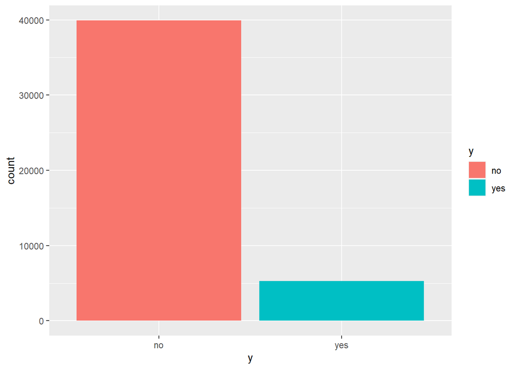

```r
# primer afegim la columna de conversió 'y'
bank.clients.y <- cbind(bank.clients, y=bank[,17])
ggplot(data=bank.clients.y,aes(x=y,fill=y))+geom_bar()
```

```r
table(bank.clients.y$y)
```

```
##
##    no   yes
## 39922  5289
```

```r
cat("La taxa de conversió del total de la mostra és de:", round(100*(5289)/(5289 + 39922), 2), "%")
```

```
## La taxa de conversió del total de la mostra és de: 11.7 %
```

Un cop fet l’estudi si orientéssim les trucades a partir del resultat, podríem fer augmentar aquesta conversió.

Com anem a executar molts cops algunes sentències, crearem funcions i executarem.

```r
# genera taula amb grups
groups <- function (data, column) {
  ret <- data %>%  group_by(data[,column]) %>% summarise (n = n()) %>% mutate(freq = signif(n / sum(n) * 100, 3))
  ret <- setNames(ret, c(column, "counts", "freq"))
  return (ret)
}

# mostra distribució i conversió
customPlot <- function(df, .x_var, .y_var) {
  # convert strings to variable
  x_var <- sym(.x_var)
  y_var <- sym(.y_var)

  groups <- groups(df, .x_var)

  print(ggplot(data=df,aes(x= !! x_var, fill = !! y_var)) + geom_bar(position="fill") + ylab("Frequency") )
  print(ggplot(groups, aes(x = !! x_var, y = counts, fill=!! x_var)) + geom_bar(stat = "identity"))


}

# retorna distribució
customPlotDist <- function(df, .x_var, .y_var) {
  # convert strings to variable
  x_var <- sym(.x_var)

  groups <- groups(df, .x_var)

  return (ggplot(groups, aes(x = !! x_var, y = counts, fill=!! x_var)) + geom_bar(stat = "identity") +  geom_text(size=3, aes(label = counts), vjust = -0.3) + geom_text(size=3, aes(label = paste(freq, "%")), vjust = 2))
}

# retorna conversió de 'y' normalitzada
customPlotNorm <- function(df, .x_var, .y_var) {
  x_var <- sym(.x_var)
  y_var <- sym(.y_var)
  return (ggplot(data=df,aes(x= !! x_var, fill = !! y_var)) + geom_bar(position="fill") + ylab("Frequency") )
}
```

#### 3.2.2.2 Estudi de l’atribut ‘age’:

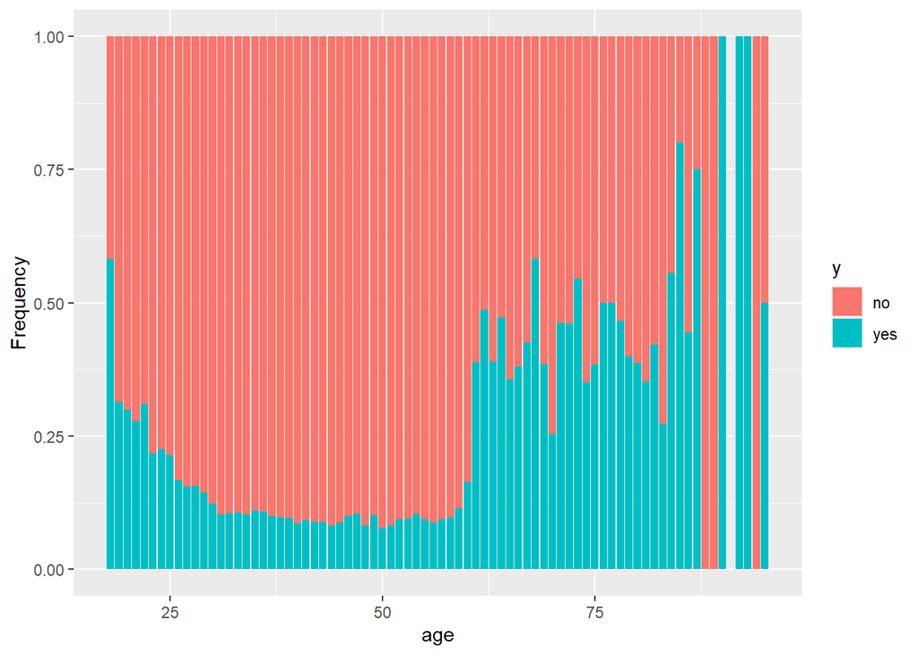

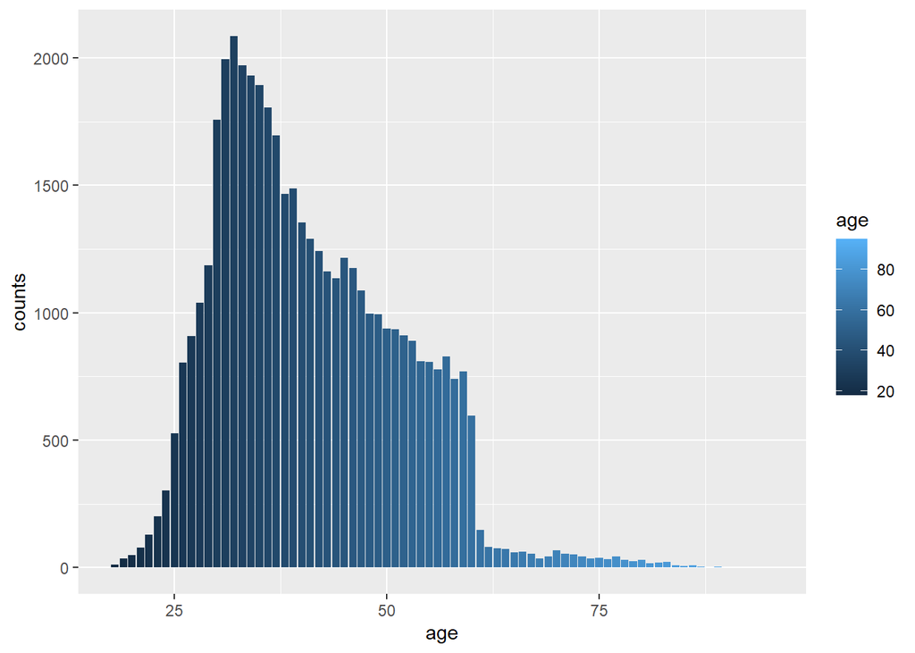

```r
customPlot(bank.clients.y,'age', 'y')
```

La primera gràfica ens mostra la conversió en funció de l’edat. En una primera visualització veiem força clarament que en una franja d’edat la conversió és similar i en els extrems millora. Podria ser que en els extrems augmenti perquè no tenim prou mostra o bé que hi hagi una franja entre els 60 i els 75 anys que ens podria dir que en aquesta la conversió és millor.

També podem intuir que tenim possibles outliers.

#### 3.2.2.3 Estudi de l’atribut ‘job’:

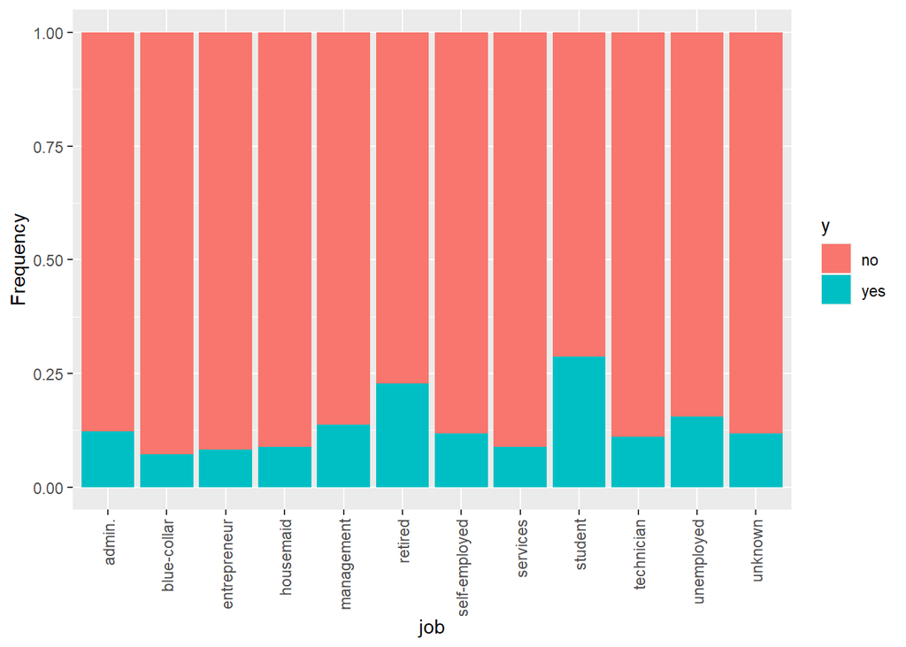

```r
with(customPlotDist(bank.clients.y,'job', 'y')  + ggpubr::rotate_x_text(),
customPlotNorm(bank.clients.y,'job', 'y') + ggpubr::rotate_x_text())
```

Aquí sí que podem veure per ordre de millor conversió: * els ‘student’ i els ‘retired’ * els unemployed i management  
* els self-employed, technician i admin * la resta tenen una tendència a contractar més que no pas els altres jobs,

En canvi, blue-collar serien el pitjor target.

#### 3.2.2.4 Estudi de l’atribut ‘marital’:

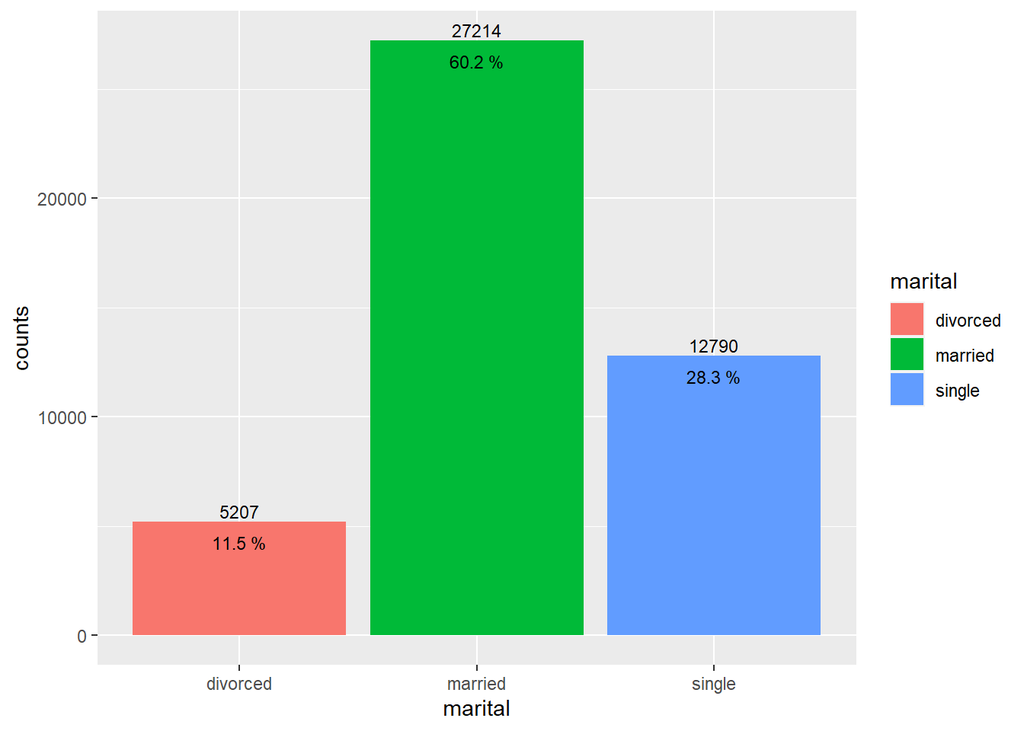

```r
customPlotDist(bank.clients.y,'marital', 'y')
```

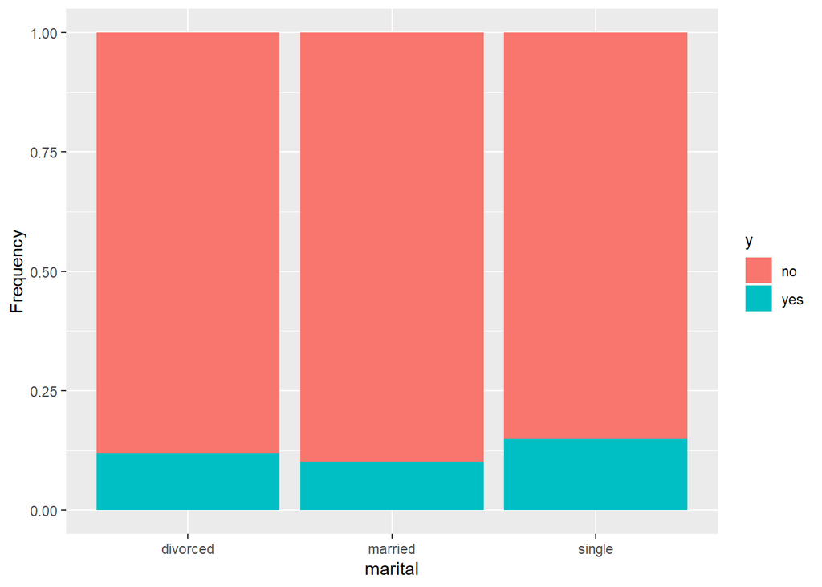

```r
customPlotNorm(bank.clients.y,'marital', 'y')
```

Sembla que els single converteixen una mica millor, després divorced i finalment married.

#### 3.2.2.5 Estudi de l’atribut ‘education’:

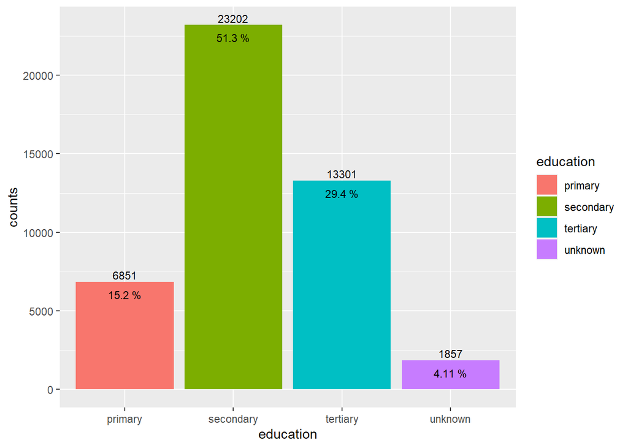

```r
customPlotDist(bank.clients.y,'education', 'y')
```

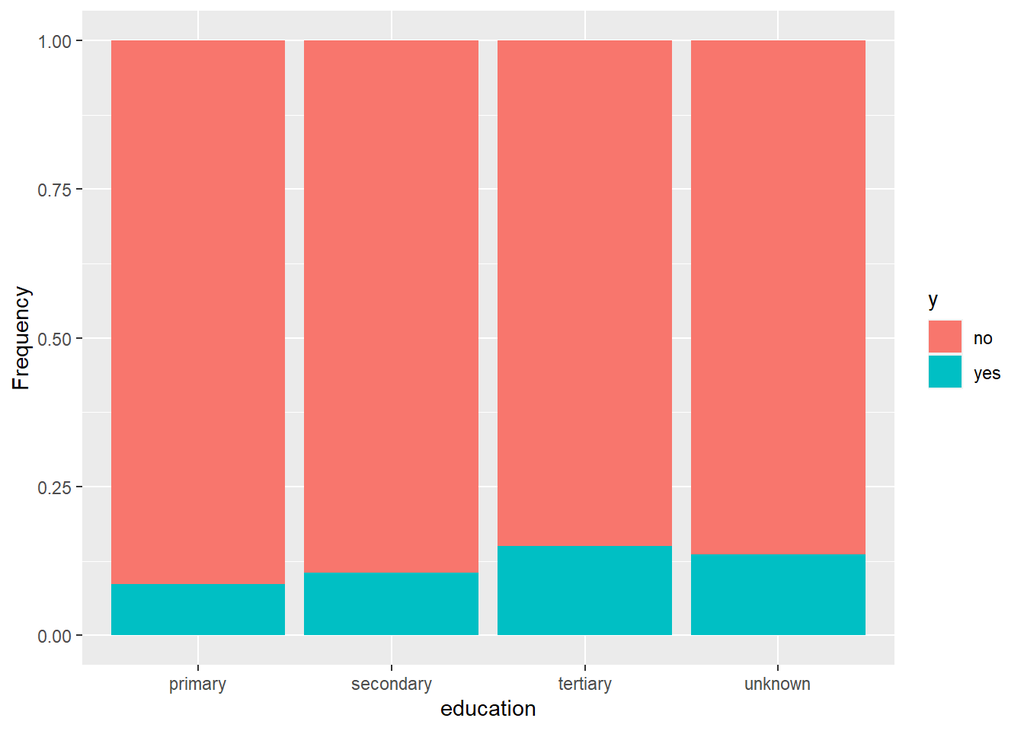

```r
customPlotNorm(bank.clients.y,'education', 'y')
```

En el cas de education primer atacaríem als tertiary, secondary i finalment primary. Els unknown si els tractem com una categoria més també són una bona elecció.

#### 3.2.2.6 Estudi de l’atribut ‘default’:

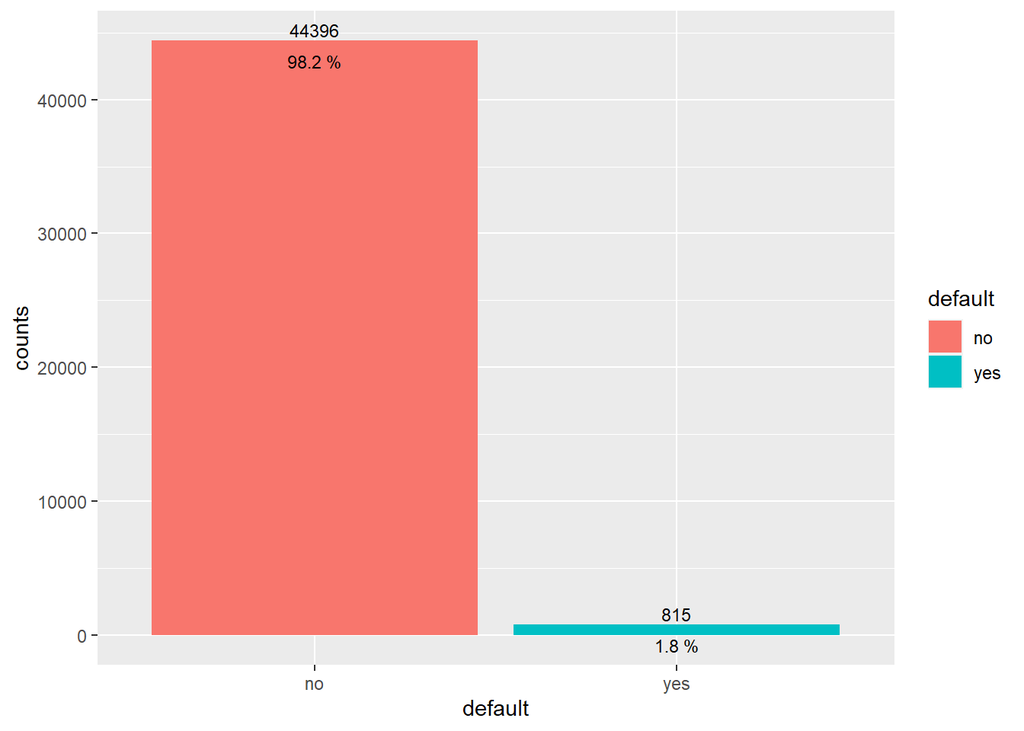

```r
customPlotDist(bank.clients.y,'default', 'y')
```

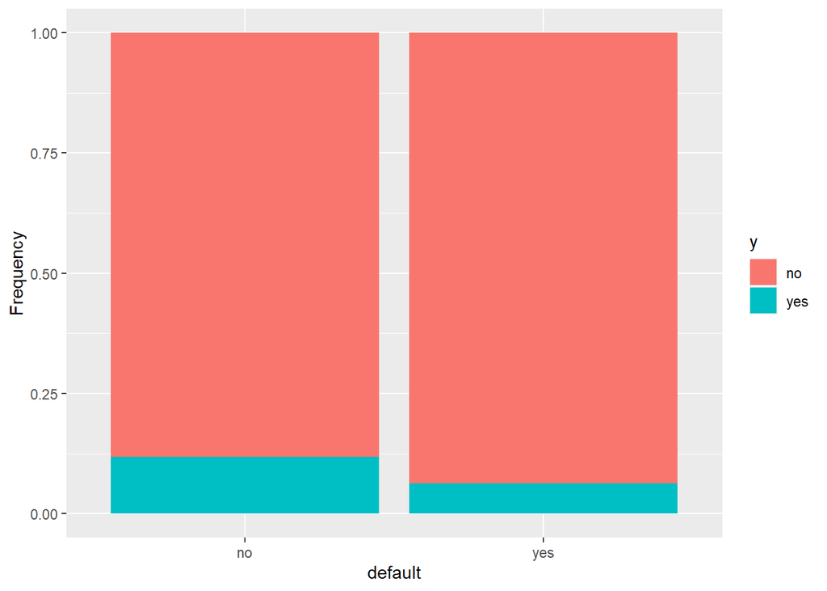

```r
customPlotNorm(bank.clients.y,'default', 'y')
```

Aquesta dada no ens aporta molt. Tenim pocs registes que son = ‘yes’. De totes maneres sembla que converteix millor el ‘no’. Registre candidat a ser eliminat segurament, ja que no tenim una mostra diferenciada i la conversió és similar. Ho veurem amb l’estudi PCA segurament.

#### 3.2.2.7 Estudi dels atributs ‘housing’ i ‘loan’:

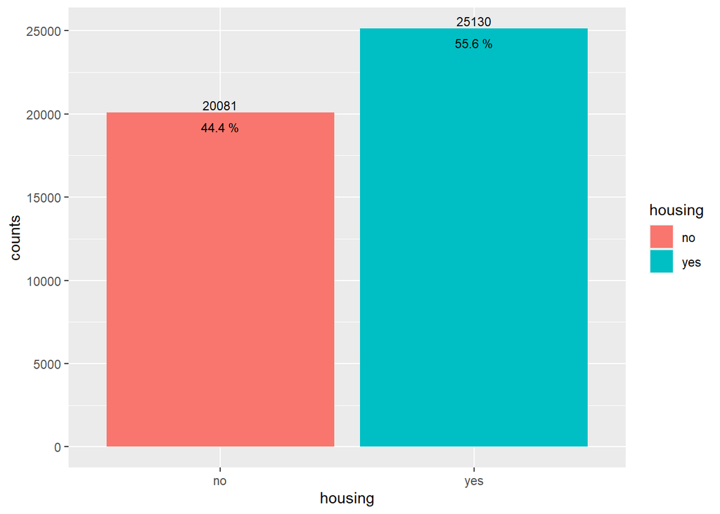

```r
customPlotDist(bank.clients.y,'housing', 'y')
```

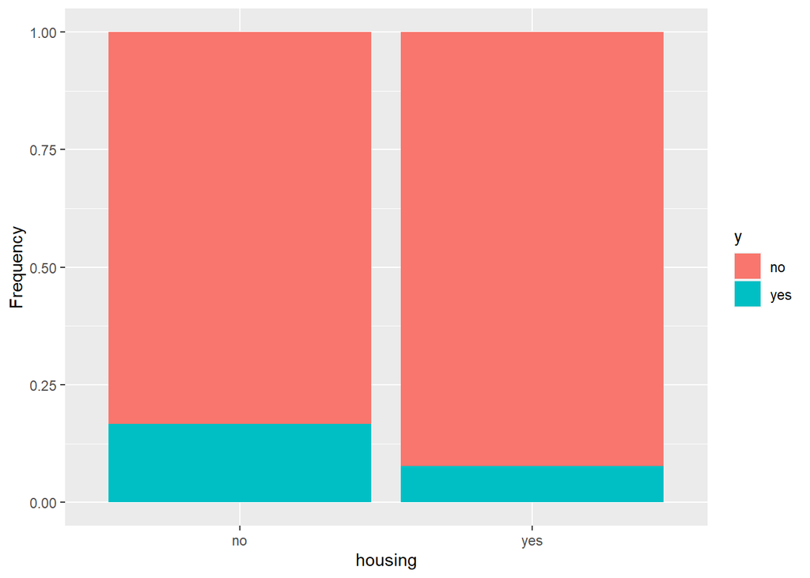

```r
customPlotNorm(bank.clients.y,'housing', 'y')
```

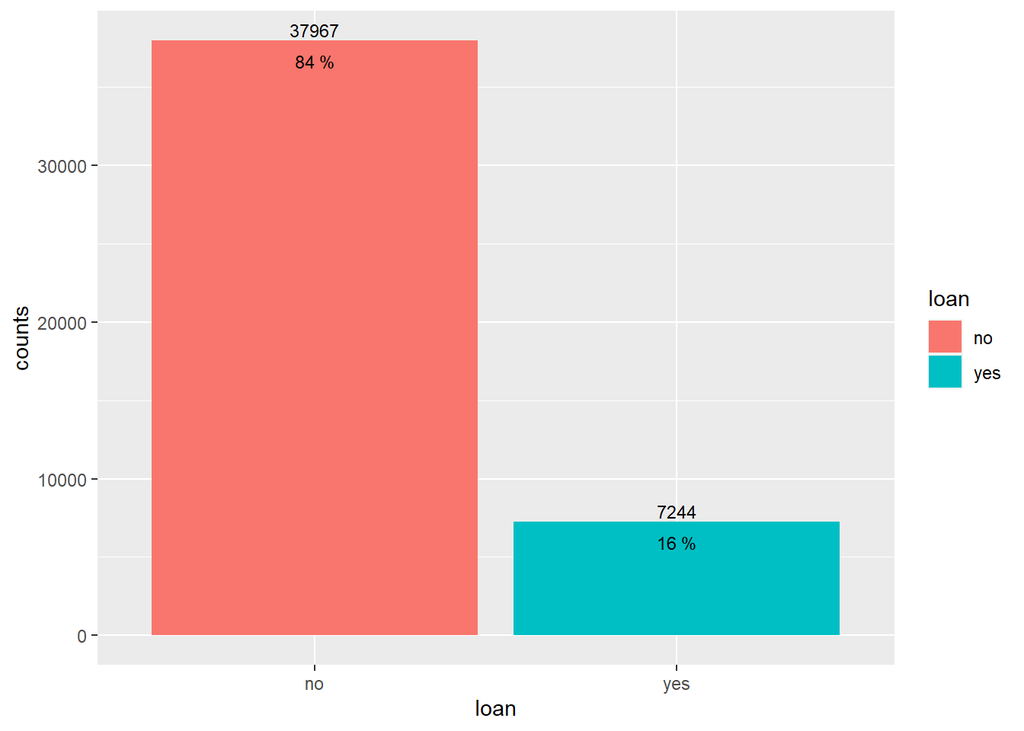

```r
customPlotDist(bank.clients.y,'loan', 'y')
```

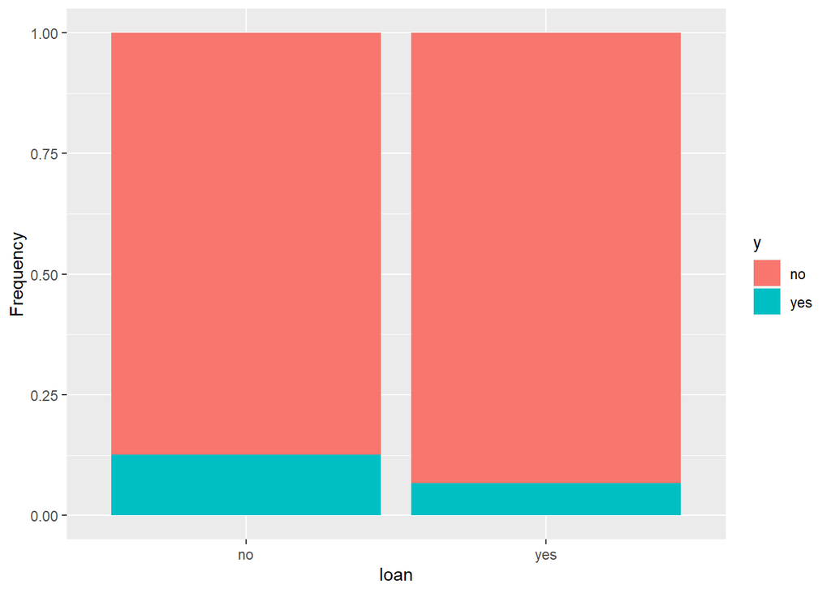

```r
customPlotNorm(bank.clients.y,'loan', 'y')
```

En quant a housing converteix força millor si no tenen préstec d’habitatge i també converteixen millor si no tenen préstec personal.

Resum:

- Amb les dades observades veig un possible target per fer una campanya per obtenir préstecs segmentant els atributs de age, jobs, marital, education, loan i housing.
- L’atribut default potser el podríem treure ja que no ens aporta gaire valor. La majoria són ‘no’.

#### 3.2.2.8 Generem comparatives amb 2 variables (job i marital) més la sortida ‘y’

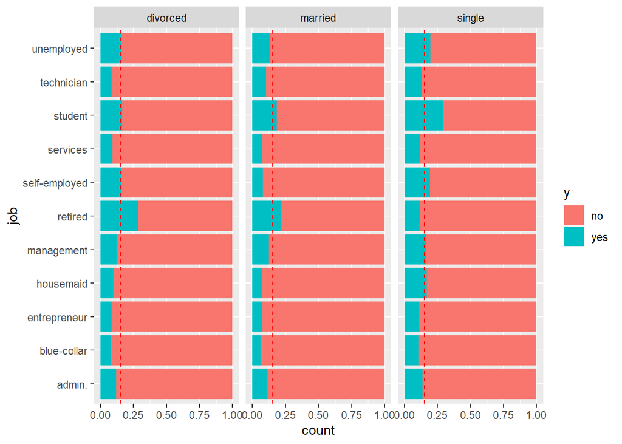

```r
# eliminem unknown's
subset <- subset(bank.clients.y, job != "unknown")
ggplot(data = subset,aes(x=job,fill=y)) + geom_bar(position="fill") + facet_wrap(~marital)+ coord_flip()  + geom_hline(yintercept=0.15, linetype="dashed",  color = "red", size=0.5)
```

Trobem altre possible informació. Bones combinacions amb:

- unemployed, sempre però sobretot amb single
- student, sempre però sobretot amb single
- self-employed amb divorced i single
- retired amb divorced i married sobretot
- management amb single
- housemaid amb single

Com a mala opció:

- blue-collar en general
- entrepreneur en general
- services, self-employed, housemaid amb married

#### 3.2.2.9 Generem comparatives amb 2 variables (job i education) més la sortida ‘y’

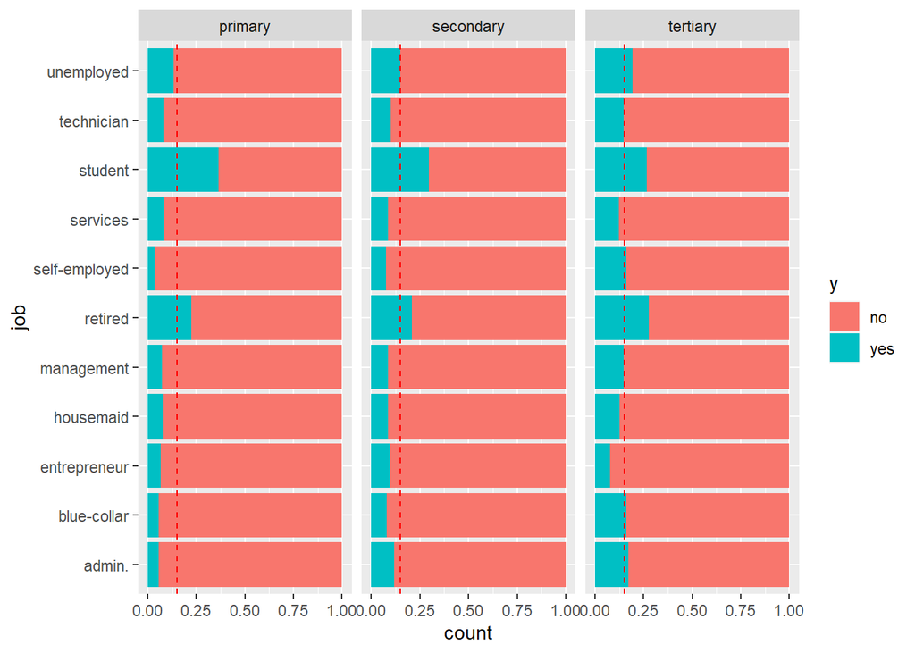

```r
# eliminem unknown's
subset <-subset(bank.clients.y, education != "unknown")
subset <- subset(subset, job != "unknown")
ggplot(data = subset,aes(x=job,fill=y)) + geom_bar(position="fill") + facet_wrap(~education)+ coord_flip()+ geom_hline(yintercept=0.15, linetype="dashed",  color = "red", size=0.5)
```

Veiem clarament que tertiary és el millor grup de education.

### 3.2.3 Anàlisi de les dades del darrer contacte de la campanya actual

```r
bank.lastcontact <- bank[,9:12]
bank.lastcontact.y <- cbind(bank.lastcontact, y=bank[,17])
head(bank.lastcontact.y)
```

```
##   contact day month duration  y
## 1 unknown   5   may      261 no
## 2 unknown   5   may      151 no
## 3 unknown   5   may       76 no
## 4 unknown   5   may       92 no
## 5 unknown   5   may      198 no
## 6 unknown   5   may      139 no
```

```r
summary(bank.lastcontact)
```

```
##       contact           day            month          duration
##  cellular :29285   Min.   : 1.00   may    :13766   Min.   :   0.0
##  telephone: 2906   1st Qu.: 8.00   jul    : 6895   1st Qu.: 103.0
##  unknown  :13020   Median :16.00   aug    : 6247   Median : 180.0
##                    Mean   :15.81   jun    : 5341   Mean   : 258.2
##                    3rd Qu.:21.00   nov    : 3970   3rd Qu.: 319.0
##                    Max.   :31.00   apr    : 2932   Max.   :4918.0
##                                    (Other): 6060
```

En una primera observació deduïm:

```r
colSums(is.na(bank.lastcontact))
```

```
##  contact      day    month duration
##        0        0        0        0
```

En les dades de darrer contacte tampoc hi ha valors null, però si molts unknown a l’atribut contact.

Visualitzem les dades i taxa de conversió per cada un dels atributs.

#### 3.2.3.1 Estudi de l’atribut ‘contact’:

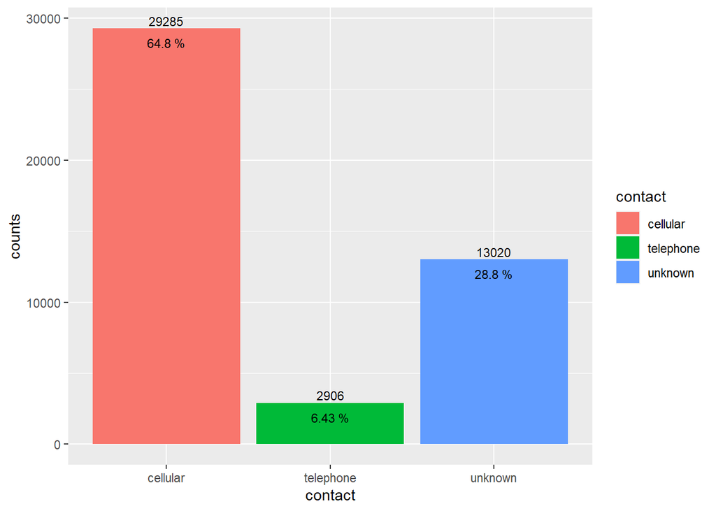

```r
customPlotDist(bank.lastcontact.y,'contact', 'y')
```

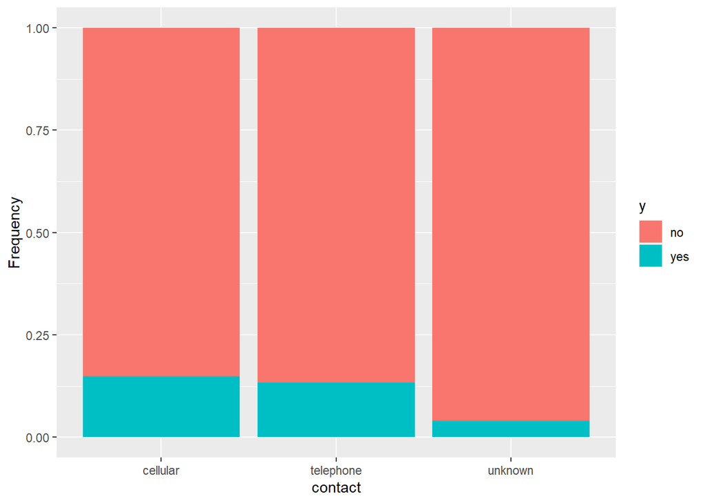

```r
customPlotNorm(bank.lastcontact.y,'contact', 'y')
```

A contact tenim molts ‘unknown’ o la conversió és dolenta. Entre cellular i telephone no hi ha molta diferència.

#### 3.2.3.2 Estudi de l’atribut ‘day’:

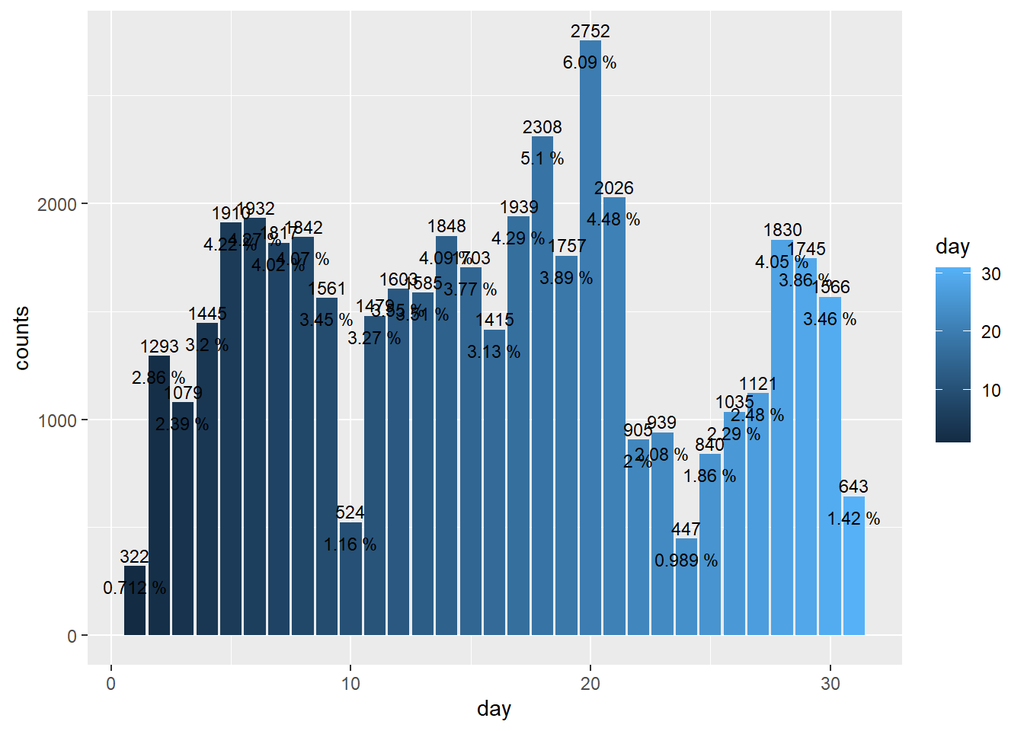

```r
customPlotDist(bank.lastcontact.y,'day', 'y')
```

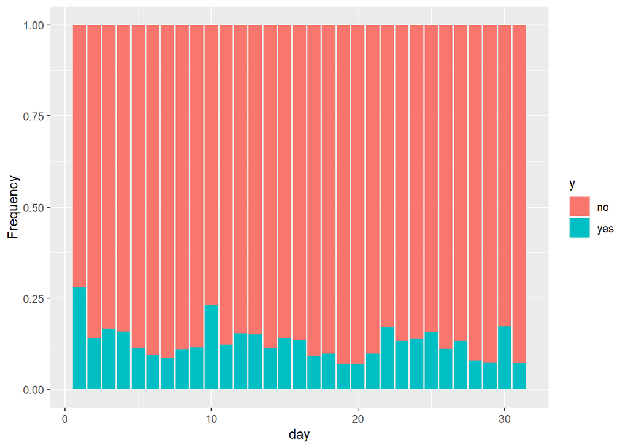

```r
customPlotNorm(bank.lastcontact.y,'day', 'y')
```

El dia del mes no ens diu gaire. Hagués estar millor tenir el dia de la setmana, crec que es més rellevant.

#### 3.2.3.3 Estudi de l’atribut ‘month’:

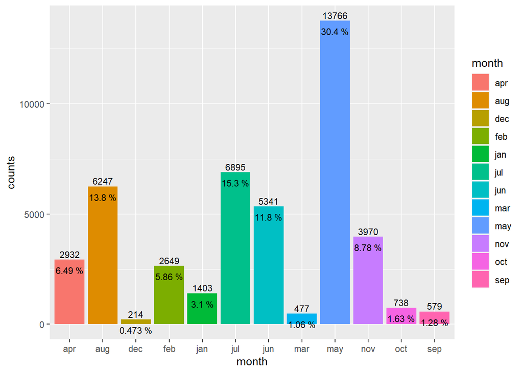

```r
customPlotDist(bank.lastcontact.y,'month', 'y')
```

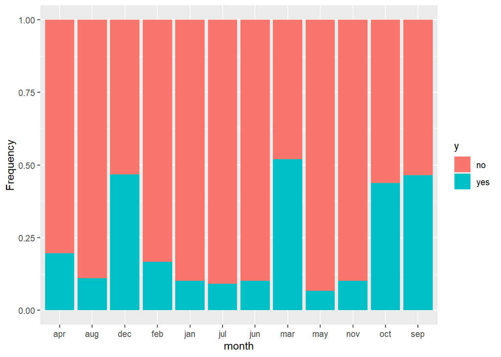

```r
customPlotNorm(bank.lastcontact.y,'month', 'y')
```

#### 3.2.3.4 Estudi de l’atribut ‘duration’:

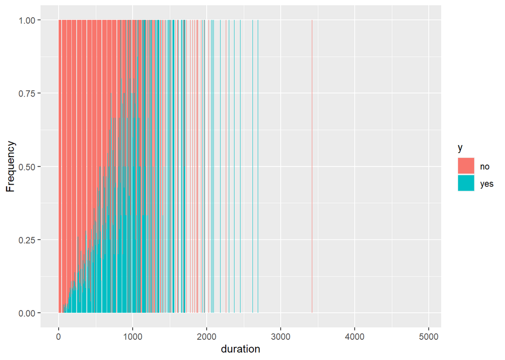

```r
customPlotNorm(bank.lastcontact.y,'duration', 'y')
```

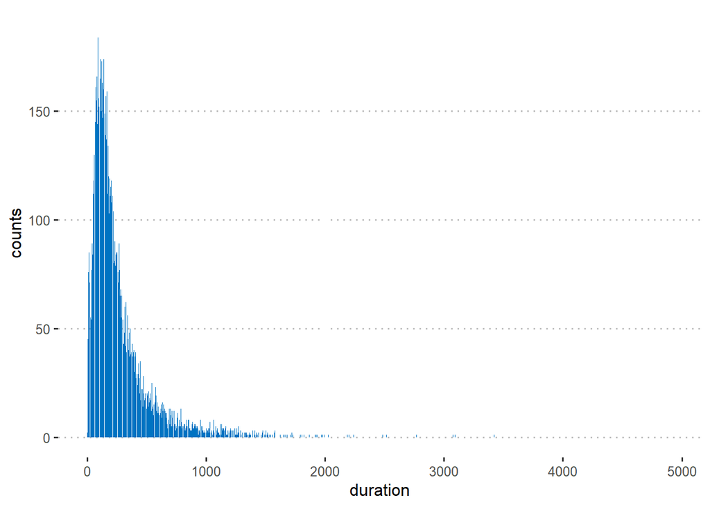

```r
duration.groups <- bank.lastcontact.y %>% group_by(duration) %>% summarise(counts = n())
ggplot(duration.groups, aes(x = duration, y = counts)) + geom_bar(fill = "#0073C2FF", stat = "identity")  + theme_pubclean()
```

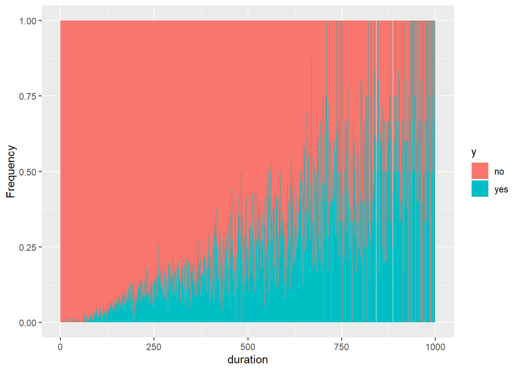

```r
ggplot(data=bank.lastcontact.y,aes(x=duration,fill=y)) + geom_bar(position="fill") + ylab("Frequency") + scale_x_continuous(limits = c(0, 1000))
```

Com més dura la trucada més posibilitats de contractar. A la primera gràfica es veu clarament que tenim valors molt atípics i no es pot apreciar bé la distribució. **Hem tallat a 1000 segons perquè per sobre no tenen sentit on la mostra és molt petita. En les tasques de neteja treure’m valors atípics**

#### 3.2.3.5 Conclusions de les dades del darrer contacte:

Contact, duration i month ens serveixen per a poder orientar la conversió al “yes”:

- No hi ha molta diferència entre telephone i cellular.
- Tenim uns mesos millor que altres. Millor *mar, apr, sep, oct, dec* que *may, jun, jul, aug, nov*. Segurament serà per estacionalitat o perquè en els millors mesos el volum és més baix i les trucades més llargues.
- Del dia del mes no podem induir gaire cosa. Si que hi ha dies millors però respecte a 12 mesos es complicat.
- Duration: com més dura la trucada millor. Sembla important mantenir l’usuari al telèfon.

### 3.2.4 Altres dades:

```r
bank.other <- bank[,13:16]
bank.other.y <- cbind(bank.other, y=bank[,17])
head(bank.other.y)
```

```
##   campaign pdays previous poutcome  y
## 1        1    -1        0  unknown no
## 2        1    -1        0  unknown no
## 3        1    -1        0  unknown no
## 4        1    -1        0  unknown no
## 5        1    -1        0  unknown no
## 6        1    -1        0  unknown no
```

```r
summary(bank.other)
```

```
##     campaign          pdays          previous           poutcome
##  Min.   : 1.000   Min.   : -1.0   Min.   :  0.0000   failure: 4901
##  1st Qu.: 1.000   1st Qu.: -1.0   1st Qu.:  0.0000   other  : 1840
##  Median : 2.000   Median : -1.0   Median :  0.0000   success: 1511
##  Mean   : 2.764   Mean   : 40.2   Mean   :  0.5803   unknown:36959
##  3rd Qu.: 3.000   3rd Qu.: -1.0   3rd Qu.:  0.0000
##  Max.   :63.000   Max.   :871.0   Max.   :275.0000
```

- campaign: sembla tenir outliers ja que el 3Q està a 3 i tenim un 63.
- previous: el mateix passar amb previous
- poutcome: té molts valors unknown que no esborrare per no reduïr tant la mostra i ens serviran com a altre categoria

```r
colSums(is.na(bank.other))
```

```
## campaign    pdays previous poutcome
##        0        0        0        0
```

Visualitzem les dades i taxa de conversió per cada un dels atributs.

#### 3.2.4.1 Estudi de l’atribut ‘campaign’:

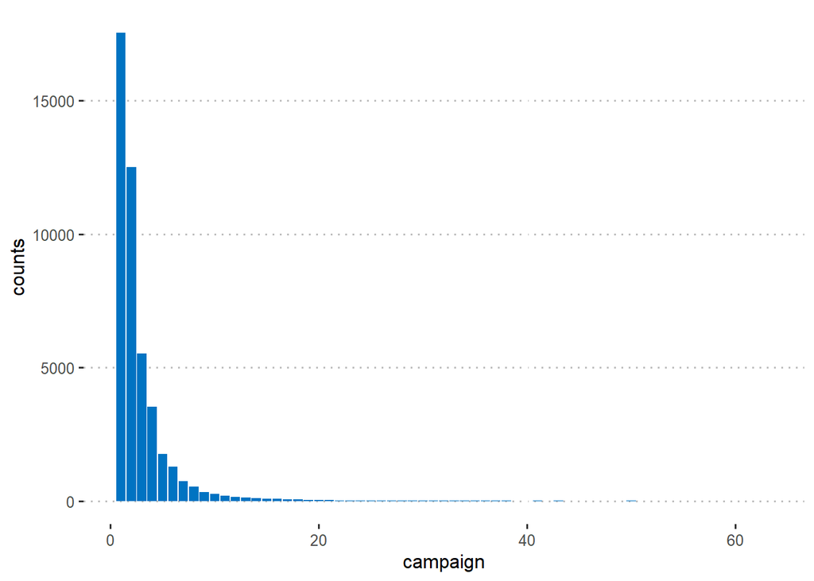

```r
campaign.groups <- bank.other.y %>% group_by(campaign) %>% summarise(counts = n())
ggplot(campaign.groups, aes(x = campaign, y = counts)) + geom_bar(fill = "#0073C2FF", stat = "identity")  + theme_pubclean()
```

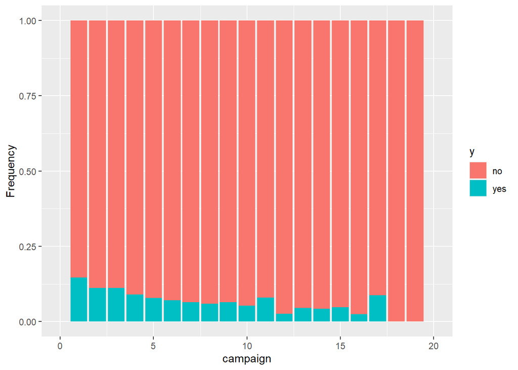

```r
ggplot(data=bank.other.y,aes(x=campaign,fill=y)) + geom_bar(position="fill") + ylab("Frequency")+ scale_x_continuous(limits = c(0, 20))
```

A partir de X trucades, potser ja no caldria trucar més perquè la probabilitat de conversió va caient. Recordem que aquest valor és el nombre de trucades en aquesta campanya.

#### 3.2.4.2 Estudi de l’atribut pdays:

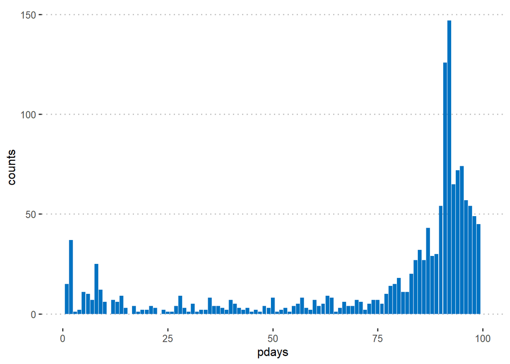

```r
pdays.groups <- bank.other.y %>% group_by(pdays) %>% summarise(counts = n())
ggplot(pdays.groups, aes(x = pdays, y = counts)) + geom_bar(fill = "#0073C2FF", stat = "identity")  + theme_pubclean() + scale_x_continuous(limits = c(0, 100))
```

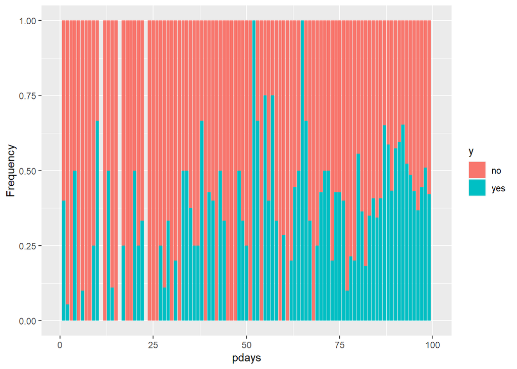

```r
ggplot(data=bank.other.y,aes(x=pdays,fill=y)) + geom_bar(position="fill") + ylab("Frequency") + scale_x_continuous(limits = c(0, 100))
```

Els dies des de la darrera trucada de la campanya anterior no ens dóna molta informació o difícil de treure una conclusió.

#### 3.2.4.3 Estudi de l’atribut previous:

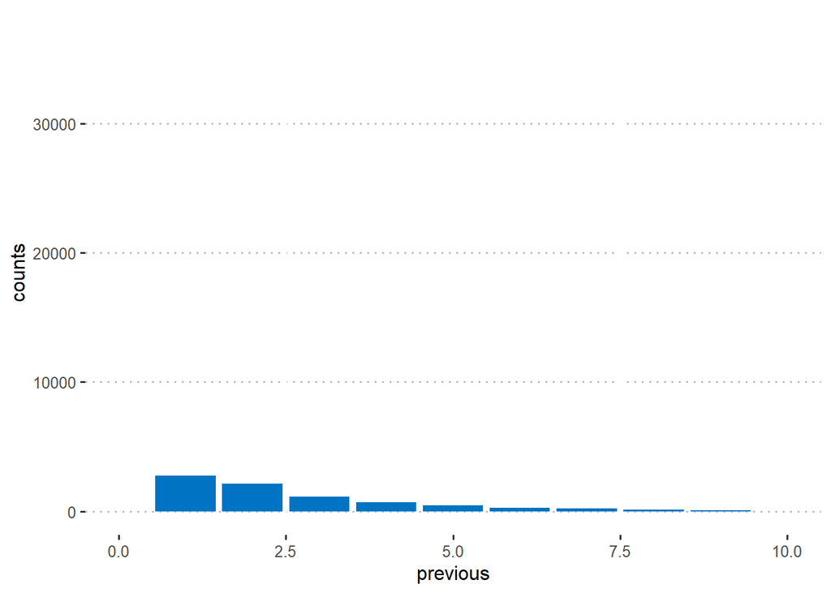

```r
previous.groups <- bank.other.y %>% group_by(previous) %>% summarise(counts = n())
ggplot(previous.groups, aes(x = previous, y = counts)) + geom_bar(fill = "#0073C2FF", stat = "identity")  + theme_pubclean()+ scale_x_continuous(limits = c(0, 10))
```

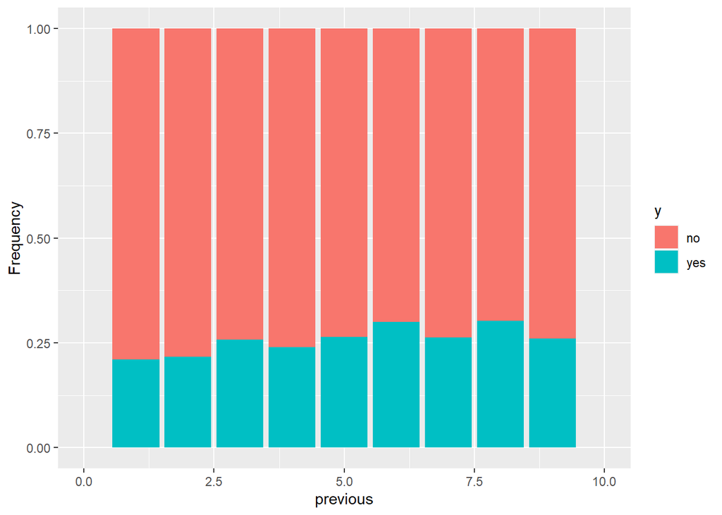

```r
ggplot(data=bank.other.y,aes(x=previous,fill=y)) + geom_bar(position="fill") + ylab("Frequency") + scale_x_continuous(limits = c(0, 10))
```

El nombre de trucades prèvies a aquesta campanya tampoc sembla molt rellevant